# Project 2

Ty Darnell

October 18, 2018

# NCAA Men’s College Baseketball Data 2017-2018 Season

Source: sportsreference.com

This is a data set of all 351 of the D1 teams. To start out with I looked at differences between the teams that made the NCAA tournament `ncaa`=1 and those that did not `ncaa`=0.

SRS – Simple Rating System A rating that takes into account average point differential and strength of schedule. The rating is denominated in points above/below average, where zero is average.

SOS – Strength of Schedule A rating of strength of schedule. The rating is denominated in points above/below average, where zero is average.

Non-Division I games are excluded from both of the above ratings.

The tables below gives the mean grouped by `NCAA` for Turnovers, Win-Loss Percentage, SOS, Three Point percentage, Field goal percentage, Free throw Percentage, Simple Rating System rating.

Teams that did not make NCAA Tournament

|  | Mean |
| --- | --- |
| Turnovers | 423.84 |
| Win-Loss % | 0.47 |
| SOS | -1.38 |
| 3 Point % | 0.35 |
| Field Goal % | 0.44 |
| Free Throw % | 0.71 |
| SRS | -3.51 |

Teams that made the NCAA Tournament

|  | Mean |
| --- | --- |
| Turnovers | 420.68 |
| Win-Loss % | 0.71 |
| SOS | 4.45 |
| 3 Point % | 0.36 |
| Field Goal % | 0.46 |
| Free Throw % | 0.72 |
| SRS | 11.61 |

It is surprising that the mean turnovers, 3 point pecentage, field goal percentage and free throw percentage are fairly similar between the two groups. It makes sense that the win loss percentage and strength of schedule are higher for the 68 teams that made the tournament.

## Strength of Schedule and Win Loss Percentage

Looking at the teams that did make the tournament there is a very weak assocation between the two variables.

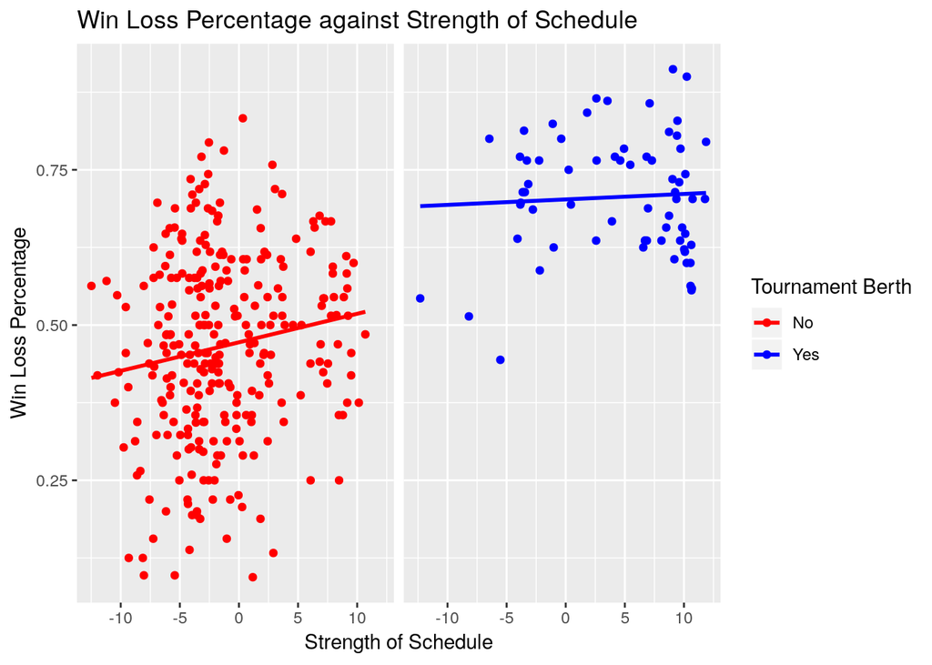

## Distribution of Simple Rating Systems Ratings

Looking at the SRS of the two groups we have the following quanitles:

Not in Tournament

|  | SRS Rating |
| --- | --- |
| 0% | -24.63 |
| 25% | -9.52 |
| 50% | -4.26 |
| 75% | 2.09 |
| 100% | 15.85 |

In Tournament

|  | SRS Rating |
| --- | --- |
| 0% | -13.19 |
| 25% | 6.70 |
| 50% | 13.81 |
| 75% | 16.98 |
| 100% | 26.64 |

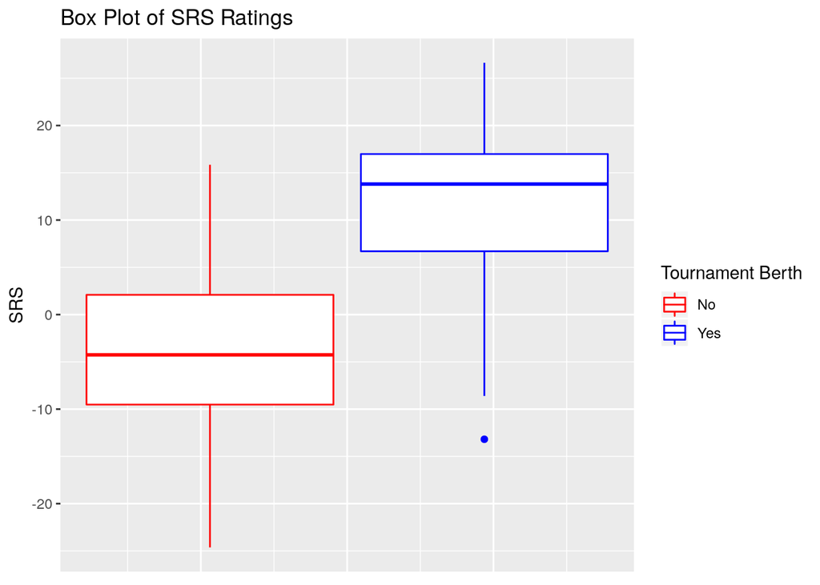

There are some teams with below average (negative) SRS ratings that made the NCAA tournament. The main reason this occurred is because teams that win their conference tournaments automatically recieve a tournament berth.

It is more difficult to explain why there are a several teams with high SRS ratings that did not make the tournament. Given that there are only 68 spots in the tournament and 351 teams, it is envitable that some teams with high SRS scores will be left out.

In order to make since of this I looked at the top 10 SRS ratings of the group that did not make the tournament.

## Top 10 Teams Left out of Tournament

All of the teams have high SOS scores and are in highly competative conferences with the expection of Saint Mary’s. They also have relatively high win loss percentages. These teams likely lost their spots to auto bid teams from less competative conferences.

SRS Top 10 Teams Out

| School | SRS | SOS | Win Loss % | Conference |
| --- | --- | --- | --- | --- |
| Penn State | 15.85 | 7.79 | 0.67 | Big Ten |
| Baylor | 14.59 | 9.17 | 0.56 | Big 12 |
| Louisville | 14.30 | 9.08 | 0.61 | ACC |
| Maryland | 13.78 | 7.94 | 0.59 | Big Ten |
| Notre Dame | 13.65 | 7.94 | 0.58 | ACC |
| Saint Mary’s (CA) | 12.86 | 0.33 | 0.83 | WCC |
| Southern California | 12.82 | 6.29 | 0.67 | Pac-12 |
| Marquette | 12.50 | 9.70 | 0.60 | Big East |
| Oklahoma State | 12.45 | 9.12 | 0.58 | Big 12 |
| Mississippi State | 11.71 | 6.82 | 0.68 | SEC |

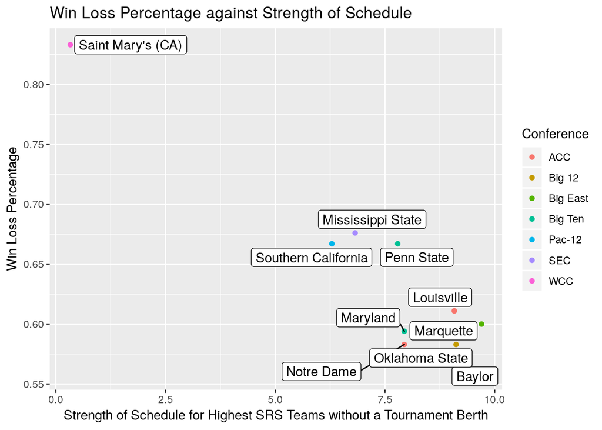